# The Strength Of Weak Bots

### *Marijn A. Keijzer & Michael Mäs*

Appendix to *manuscript*

- Supplementary figures and analyses are marked with the right-aligned header: SUPPLEMENTARY
- Code and data from the simulation experiment are retrievable via github.com/marijnkeijzer/weakbots/
- defSim is available on github.com/marijnkeijzer/defSim/

### This notebook includes:

1. Single run analyses
2. Simulation experiment
3. Statistical models
4. Sensitivity analyses

```python
import defSim as ds                # for our social influence model simulations
import random                      # allows us to set a seed for replicable simulations
import networkx as nx              # handles the construction of networks
import matplotlib as mpl           # creates graphs and plots
import matplotlib.pyplot as plt    # creates graphs and plots
import matplotlib.gridspec as gridspec   # to create grid for single run analysis figures
import pandas as pd                # to convert our results table to a nice and functional data frame
import numpy as np                 # useful math functions
import seaborn as sns              # pretty plots
import statsmodels.api as sm       # to estimate regressions
import warnings                    # used to suppress deprecation warnings in the heatgrid generator method
import itertools
```

## 1. Single run analyses

### 1.1 Functions

### 1.1.1 Simulation run function

Below is the simulation function used for the generation of the single run analyses. The code used for our larger simulations (the simulation experiment and the sensitivity analyses) was run on a HPC so the function used there is not printed here (but available in our github repository). The functions used there and the one printed here are qualitatively the same. The code used in the simulation experiment...

- ...generates different **output**: indicators as measured at the end of the run instead of at every tick.
- ...measures **timesteps** differently: ticks are only counted at non-bot influence events to control for the difference in influence opportunity between models with a very active bot compared to those with a very inactive bot.
- ..write its output directly to a separate file to accommodate **parallel processing**.

```python
def simulation_run(bot_connectedness=.25,
                   bot_activation_rate=.25,
                   N=144,
                   K=12,
                   P=0,
                   return_activity_monitor=True,
                   return_graph=False,
                   max_ticks=100000,
                   seed=None):
    """
    This function
        1. Creates the Axelrod model as a NetworkX graph object with a bot
        2. Executes similarity biased influence between
            a. the BOT and a randomly selected network neighbor (with p = bot_activation_rate)
            b. two randomly selected network neighbors (with p = 1-bot_activation_rate)
        3. Returns graph object when no further influence is possible (or after 100,000 ticks)
    """

    ## PHASE 1) INITIALIZATION

    # seed the run for replicability
    random.seed(seed)

    # generate the NetworkX graph object and intialize with F random categorical features with Q traits
    G = ds.generate_network("watts_strogatz_graph",n=N,k=K,p=P)
    ds.initialize_attributes(G, realization="random_categorical", num_features=3, num_traits=3)

    # add the bot to the graph
    agentlist = list(G.nodes())
    G.add_node("bot")
    G.nodes["bot"]["f01"] = 99    # Unique bot trait, used to track the bot's effectiveness
    G.nodes["bot"]["f02"] = 0
    G.nodes["bot"]["f03"] = 0

    # connect the bot to a proportion 'bot_connectedness' of the graph
    friends_of_bot = random.sample(agentlist, int(bot_connectedness * N))
    for j in friends_of_bot:
        G.add_edge("bot",j)

    # calculate the dissimilarity on all edges
    calculator = ds.dissimilarity_calculator.select_calculator("hamming")
    calculator.calculate_dissimilarity_networkwide(G)

    # store the indices of direct and indirect contacts of the bot
    shortest_paths = nx.shortest_path_length(G,'bot')
    agents_l1 = [key for key, val in shortest_paths.items() if val == 1]
    agents_l2 = [key for key, val in shortest_paths.items() if val >= 2]

    # initialize ticks, stop variable, and tickwise dictionaries for output
    ticks = 0
    stop = False
    bot_trait_count = [dict(count_l1=len(agents_l1),
                            count_l2=len(agents_l2))]
    activity_monitor = dict(success=[],
                            i_is_bot=[])

    ## PHASE 2) SIMULATION

    while(not stop):
        ticks += 1

        # choose sending agent
        if random.random() > bot_activation_rate:
            agent_i = ds.select_focal_agent(G,"random",agentlist=agentlist)
            activity_monitor['i_is_bot'].append(False)
        else:
            agent_i = "bot"
            activity_monitor['i_is_bot'].append(True)

        # choose receiving agent
        agent_j = ["bot"]
        while agent_j == ["bot"]:
            agent_j = [(random.choice([neighbor for neighbor in G[agent_i]]))]

        # exert influence and store whether influence was successful
        activity_monitor['success'].append(
            ds.influence_sim.spread_influence(G,"axelrod",agent_i,agent_j,"one-to-one",calculator)
        )

        # store the diffusion of the unique bot trait among first and second (or more) degree contacts
        bot_trait_count.append({'count_l1': len([1 for i in agents_l1 if G.nodes[i]['f01']==99]) / len(agents_l1),
                                'count_l2': len([1 for i in agents_l2 if G.nodes[i]['f01']==99]) / len(agents_l2)})

        # stop the execution if condition is true
        if(not any([True for i,j,d in G.edges.data('dist') if 0.1 < d < .9])
          or ticks > max_ticks):
            if(return_graph):
                return G
            if(return_activity_monitor):
                return bot_trait_count, activity_monitor
            else:
                return bot_trait_count
            stop = True
```

### 1.1.2 Method for plotting single run figure

```python
def bot_diffusion_fig_horizontal(df,am):
    # data_transformation
    infl_succ_total = np.cumsum([1 if i else 0 for i in am['success']])
    infl_succ_bot = np.cumsum([i+j-1 if i else 0 for i,j in zip(am['i_is_bot'],am['success'])])
    infl_succ_agent = np.cumsum([i+j if not i else 0 for i,j in zip(am['i_is_bot'],am['success'])])

    fig = plt.figure(constrained_layout=True,figsize=[6,3])
    gs = gridspec.GridSpec(nrows=2, ncols=3, figure=fig)

    plt.tight_layout()

    # panel A
    fig_s1 = fig.add_subplot(gs[:, :-1])
    fig_s1.text(-0.12, 1.1, "A", transform=fig_s1.transAxes, fontsize=16, fontweight='bold', va='top', ha='right')
    #fig_s1.set_title('..1..')
    fig_s1.set_ylabel('proportion')
    fig_s1.set_xlabel('time')
    fig_s1.set_ylim([0,1])
    fig_s1.plot(df['count_l2'][1:],color='green',linewidth=2)
    fig_s1.plot(df['count_l1'][1:],color='red',linewidth=2)
    fig_s1.plot(
        list((df['count_l1'][1:] * (df['count_l1'][0] / 144) +
              df['count_l2'][1:] * (df['count_l2'][0] / 144))),
        color='blue',linewidth=2)

    # panel B
    fig_s2 = fig.add_subplot(gs[0, -1])
    fig_s2.text(-0.12, 1.2, "B", transform=fig_s2.transAxes, fontsize=16, fontweight='bold', va='top', ha='right')
    #fig_s2.set_title('..2..')
    fig_s2.set_ylabel('count')
    fig_s2.set_xlabel('time')
    fig_s2.set_ylim([0,144])

    fig_s2.plot(df['count_l2'][1:] * df['count_l2'][0],color='green',linewidth=2)
    fig_s2.plot(df['count_l1'][1:] * df['count_l1'][0],color='red',linewidth=2)
    fig_s2.plot(
        list((df['count_l1'][1:] * df['count_l1'][0] +
              df['count_l2'][1:] * df['count_l2'][0])),
        color='blue',linewidth=2)

    # panel C
    fig_s3 = fig.add_subplot(gs[1, -1])
    fig_s3.text(-0.12, 1.2, "C", transform=fig_s3.transAxes, fontsize=16, fontweight='bold', va='top', ha='right')
    #fig_s2.set_title('..3..')
    fig_s3.set_ylabel('activity')
    fig_s3.set_xlabel('time')
    fig_s3.plot(infl_succ_agent, color='red', linewidth=2)
    fig_s3.plot(infl_succ_bot, color='green', linewidth=2)
    fig_s3.plot(infl_succ_total, color='blue', linewidth=2)

    return fig
```

### 1.2. Individual runs

#### LOW activity / LOW connectedness

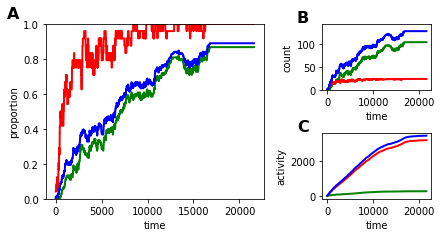

```python
df_ll, am_ll = simulation_run(bot_connectedness=24/144,bot_activation_rate=24/144,seed=3010)
df_ll = pd.DataFrame(df_ll)
fig = bot_diffusion_fig_horizontal(df_ll,am_ll)

fig.savefig('plots/singleRun_loA-loC.png', dpi=300, bbox_inches='tight')
```

#### HIGH activity / LOW connectedness

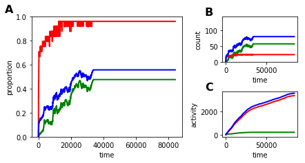

```python
df_hl, am_hl = simulation_run(bot_connectedness=24/144,bot_activation_rate=96/144,seed=119)
df_hl = pd.DataFrame(df_hl)
fig = bot_diffusion_fig_horizontal(df_hl, am_hl)

fig.savefig('plots/singleRun_hiA-loC.png',dpi=300,bbox_inches='tight')
```

#### LOW activity / HIGH connectedness

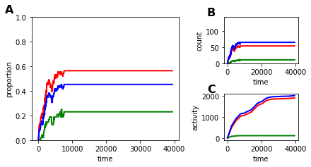

```python
df_lh, am_lh = simulation_run(bot_connectedness=96/144,bot_activation_rate=24/144,seed=142)
df_lh = pd.DataFrame(df_lh)
fig = bot_diffusion_fig_horizontal(df_lh,am_lh)

fig.savefig('plots/singleRun_loA-hiC.png',dpi=300,bbox_inches='tight')
```

#### Combined

```python
def activity_trans(am):
    infl_succ_total = np.cumsum([1 if i else 0 for i in am['success']])
    infl_succ_bot = np.cumsum([i+j-1 if i else 0 for i,j in zip(am['i_is_bot'],am['success'])])
    infl_succ_agent = np.cumsum([i+j if not i else 0 for i,j in zip(am['i_is_bot'],am['success'])])

    return(infl_succ_total, infl_succ_bot, infl_succ_agent)
```

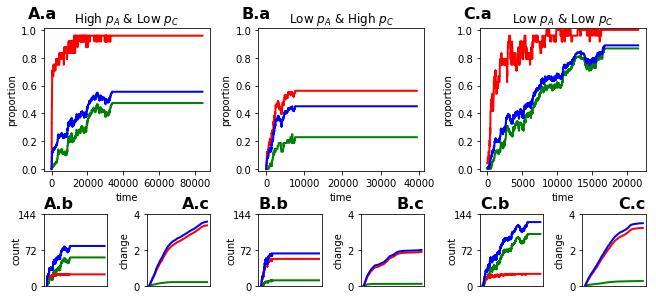

```python
panelNames = ["A.a","A.b","A.c","B.a","B.b","B.c","C.a","C.b","C.c"]

fig = plt.figure(constrained_layout=True,figsize=[9,4])
gs = gridspec.GridSpec(nrows=3, ncols=6, figure=fig)

## PANEL A -------------------------------------------------------------------------
infl_succ_total, infl_succ_bot, infl_succ_agent = activity_trans(am_hl)

# panel A.a
ax1 = fig.add_subplot(gs[0:2, 0:2])
ax1.text(-0.1, 1.15, panelNames[0], transform=ax1.transAxes,
            fontsize=16, fontweight='bold', va='top', ha='left')
ax1.set_title('High $p_A$ & Low $p_C$')
ax1.set_ylabel('proportion')
ax1.set_xlabel('time')
ax1.set_ylim([0,1])
ax1.set_ylim([-0.015,1.015])
ax1.plot(df_hl['count_l2'][1:],color='green',linewidth=2)
ax1.plot(df_hl['count_l1'][1:],color='red',linewidth=2)
ax1.plot(
    list((df_hl['count_l1'][1:] * (df_hl['count_l1'][0] / 144) +
          df_hl['count_l2'][1:] * (df_hl['count_l2'][0] / 144))), color='blue',linewidth=2)

# panel A.b
ax2 = fig.add_subplot(gs[-1, 0])
ax2.text(0, 1.25, panelNames[1], transform=ax2.transAxes,
            fontsize=16, fontweight='bold', va='top', ha='left')
ax2.set_ylabel('count')
ax2.yaxis.set_label_coords(-0.35,.5)
ax2.axes.get_xaxis().set_visible(False)
ax2.set_ylim([0,144])
plt.yticks([0,72,144])


ax2.plot(df_hl['count_l2'][1:] * df_hl['count_l2'][0],color='green',linewidth=2)
ax2.plot(df_hl['count_l1'][1:] * df_hl['count_l1'][0],color='red',linewidth=2)
ax2.plot(
    list((df_hl['count_l1'][1:] * df_hl['count_l1'][0] +
          df_hl['count_l2'][1:] * df_hl['count_l2'][0])), color='blue',linewidth=2)

# panel A.c
ax3 = fig.add_subplot(gs[-1, 1])
ax3.text(1, 1.25, panelNames[2], transform=ax3.transAxes,
            fontsize=16, fontweight='bold', va='top', ha='right')
ax3.set_ylabel('change')
ax3.axes.get_xaxis().set_visible(False)
ax3.plot(infl_succ_agent/1000, color='red', linewidth=2)
ax3.plot(infl_succ_bot/1000, color='green', linewidth=2)
ax3.plot(infl_succ_total/1000, color='blue', linewidth=2)
ax3.set_ylim([0,4])
plt.yticks([0,2,4])

## PANEL B -------------------------------------------------------------------------
infl_succ_total, infl_succ_bot, infl_succ_agent = activity_trans(am_lh)

# panel B.a
ax4 = fig.add_subplot(gs[0:2, 2:4])
ax4.text(-0.1, 1.15, panelNames[3], transform=ax4.transAxes,
            fontsize=16, fontweight='bold', va='top', ha='left')
ax4.set_title('Low $p_A$ & High $p_C$')
ax4.set_ylabel('proportion')
ax4.set_xlabel('time')
ax4.set_ylim([-0.015,1.015])
ax4.plot(df_lh['count_l2'][1:],color='green',linewidth=2)
ax4.plot(df_lh['count_l1'][1:],color='red',linewidth=2)
ax4.plot(
    list((df_lh['count_l1'][1:] * (df_lh['count_l1'][0] / 144) +
          df_lh['count_l2'][1:] * (df_lh['count_l2'][0] / 144))), color='blue',linewidth=2)

# panel B.b
ax5 = fig.add_subplot(gs[-1, 2])
ax5.text(0, 1.25, panelNames[4], transform=ax5.transAxes,
            fontsize=16, fontweight='bold', va='top', ha='left')
ax5.yaxis.set_label_coords(-0.35,.5)
ax5.set_ylabel('count')
ax5.axes.get_xaxis().set_visible(False)
ax5.set_ylim([0,144])
plt.yticks([0,72,144])


ax5.plot(df_lh['count_l2'][1:] * df_lh['count_l2'][0],color='green',linewidth=2)
ax5.plot(df_lh['count_l1'][1:] * df_lh['count_l1'][0],color='red',linewidth=2)
ax5.plot(
    list((df_lh['count_l1'][1:] * df_lh['count_l1'][0] +
          df_lh['count_l2'][1:] * df_lh['count_l2'][0])), color='blue',linewidth=2)

# panel B.c
ax6 = fig.add_subplot(gs[-1, 3])
ax6.text(1, 1.25, panelNames[5], transform=ax6.transAxes,
            fontsize=16, fontweight='bold', va='top', ha='right')
ax6.set_ylabel('change')
ax6.axes.get_xaxis().set_visible(False)
ax6.plot(infl_succ_agent/1000, color='red', linewidth=2)
ax6.plot(infl_succ_bot/1000, color='green', linewidth=2)
ax6.plot(infl_succ_total/1000, color='blue', linewidth=2)
ax6.set_ylim([0,4])
plt.yticks([0,2,4])

## panel C -------------------------------------------------------------------------
infl_succ_total, infl_succ_bot, infl_succ_agent = activity_trans(am_ll)

# panel C.a
ax7 = fig.add_subplot(gs[0:2, 4:])
ax7.text(-0.1, 1.15, panelNames[6], transform=ax7.transAxes,
            fontsize=16, fontweight='bold', va='top', ha='left')
ax7.set_title('Low $p_A$ & Low $p_C$')
ax7.set_ylabel('proportion')
ax7.set_xlabel('time')
ax7.set_ylim([-0.015,1.015])
ax7.plot(df_ll['count_l2'][1:],color='green',linewidth=2)
ax7.plot(df_ll['count_l1'][1:],color='red',linewidth=2)
ax7.plot(
    list((df_ll['count_l1'][1:] * (df_ll['count_l1'][0] / 144) +
          df_ll['count_l2'][1:] * (df_ll['count_l2'][0] / 144))), color='blue',linewidth=2)

# panel C.b
ax8 = fig.add_subplot(gs[-1, 4])
ax8.text(0, 1.25, panelNames[7], transform=ax8.transAxes,
            fontsize=16, fontweight='bold', va='top', ha='left')
ax8.yaxis.set_label_coords(-0.35,.5)
ax8.set_ylabel('count')
ax8.axes.get_xaxis().set_visible(False)
ax8.set_ylim([0,144])
plt.yticks([0,72,144])


ax8.plot(df_ll['count_l2'][1:] * df_ll['count_l2'][0],color='green',linewidth=2)
ax8.plot(df_ll['count_l1'][1:] * df_ll['count_l1'][0],color='red',linewidth=2)
ax8.plot(
    list((df_ll['count_l1'][1:] * df_ll['count_l1'][0] +
          df_ll['count_l2'][1:] * df_ll['count_l2'][0])), color='blue',linewidth=2)

# panel C.c
ax9 = fig.add_subplot(gs[-1, 5])
ax9.text(1, 1.25, panelNames[8], transform=ax9.transAxes,
            fontsize=16, fontweight='bold', va='top', ha='right')
ax9.set_ylabel('change')
ax9.axes.get_xaxis().set_visible(False)
ax9.plot(infl_succ_agent/1000, color='red', linewidth=2)
ax9.plot(infl_succ_bot/1000, color='green', linewidth=2)
ax9.plot(infl_succ_total/1000, color='blue', linewidth=2)
ax9.set_ylim([0,4])
plt.yticks([0,2,4])

plt.show()

fig.savefig('plots/singleRuns.png',dpi=300,bbox_inches='tight')
```

#### HIGH activity / HIGH connectedness SUPPLEMENTARY

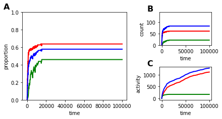

```python
df_hh, am_hh = simulation_run(bot_connectedness=96/144,bot_activation_rate=96/144,seed=141)
df_hh = pd.DataFrame(df_hh)
fig = bot_diffusion_fig_horizontal(df_hh,am_hh)

fig.savefig('plots/singleRun_hiA-hiC.png',dpi=300,bbox_inches='tight')
```

This scenario shows a mix between the lowC/highA & highC/lowA scenario's. There is rapid diffusion to the bots direct neighbors, and since the bot is highly connected here, this shows up in the total diffusion rate too.

### 1.3 Network view SUPPLEMENTARY

These plots show the diffusion of the bot trait at different points in time during the simulation run within the ring network. Nodes that adopted the trait are colored red, nodes that didn't are colored blue.

```python
# function to generate the network figures
def gen_network_fig(G):
    pos = nx.circular_layout([i for i in range(144) if i%2==0],1)
    pos.update(nx.circular_layout([i for i in range(144) if i%2==1],.8))
    pos['bot'] = [0,0]

    nodecol = ['r' if G.nodes[i]['f01'] == 99 else 'b' for i in G.nodes()]
    bin_col = plt.cm.get_cmap('binary', 4)
    edgecol = [bin_col(1 - G.edges[i]['dist']) for i in G.edges()]

    Gcopy = G.copy()
    Gcopy.remove_edges_from([i for i in G.edges() if G.edges[i]['dist'] == 1])
    nx.draw_networkx_edges(Gcopy, pos=pos, edge_color=edgecol)
    nx.draw_networkx_nodes(G, pos=pos, node_size=14, node_color=nodecol)
```

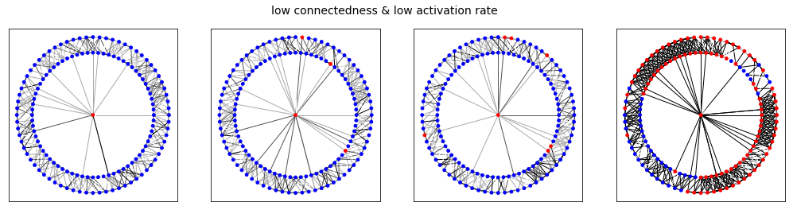

```python
plt.figure(figsize=[17.5,4])
plt.suptitle('low connectedness & low activation rate',fontsize=14)
plt.subplot(141)
gen_network_fig(simulation_run(bot_connectedness=.25, bot_activation_rate=.1, max_ticks=0, seed=1109, return_graph=True))
plt.subplot(142)
gen_network_fig(simulation_run(bot_connectedness=.25, bot_activation_rate=.1, max_ticks=100, seed=1109, return_graph=True))
plt.subplot(143)
gen_network_fig(simulation_run(bot_connectedness=.25, bot_activation_rate=.1, max_ticks=500, seed=1109, return_graph=True))
plt.subplot(144)
gen_network_fig(simulation_run(bot_connectedness=.25, bot_activation_rate=.1, max_ticks=100000, seed=1109, return_graph=True))
plt.show()
```

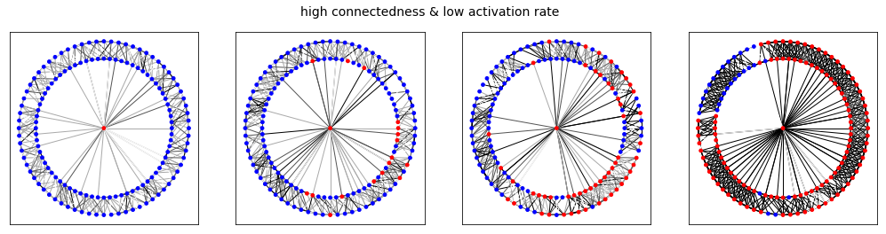

```python
plt.figure(figsize=[17.5,4])
plt.suptitle('high connectedness & low activation rate',fontsize=14)
plt.tight_layout(pad=0, w_pad=0, h_pad=0)
plt.subplot(141)
gen_network_fig(simulation_run(bot_connectedness=.5, bot_activation_rate=.1, max_ticks=0, seed=3010, return_graph=True))
plt.subplot(142)
gen_network_fig(simulation_run(bot_connectedness=.5, bot_activation_rate=.1, max_ticks=1000, seed=3010, return_graph=True))
plt.subplot(143)
gen_network_fig(simulation_run(bot_connectedness=.5, bot_activation_rate=.1, max_ticks=5000, seed=3010, return_graph=True))
plt.subplot(144)
gen_network_fig(simulation_run(bot_connectedness=.5, bot_activation_rate=.1, max_ticks=20000, seed=3010, return_graph=True))
plt.show()
```

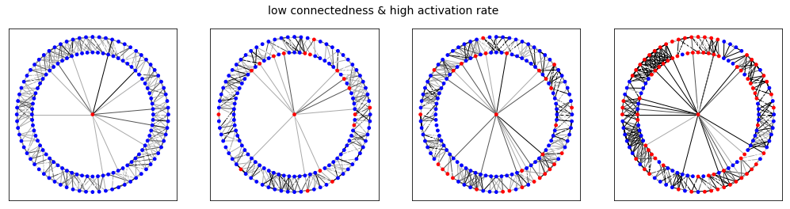

```python
plt.figure(figsize=[17.5,4])
plt.suptitle('low connectedness & high activation rate',fontsize=14)
plt.subplot(141)
gen_network_fig(simulation_run(bot_connectedness=.25, bot_activation_rate=.75, max_ticks=0, seed=1401, return_graph=True))
plt.subplot(142)
gen_network_fig(simulation_run(bot_connectedness=.25, bot_activation_rate=.75, max_ticks=1000, seed=1401, return_graph=True))
plt.subplot(143)
gen_network_fig(simulation_run(bot_connectedness=.25, bot_activation_rate=.75, max_ticks=5000, seed=1401, return_graph=True))
plt.subplot(144)
gen_network_fig(simulation_run(bot_connectedness=.25, bot_activation_rate=.75, max_ticks=20000, seed=1401, return_graph=True))
plt.show()
```

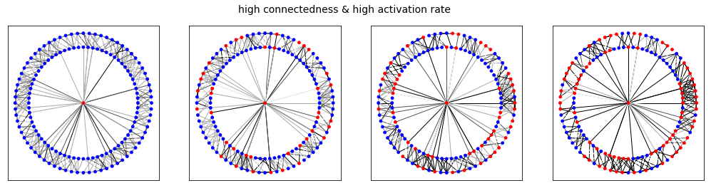

```python
plt.figure(figsize=[17.5,4])
plt.suptitle('high connectedness & high activation rate',fontsize=14)
plt.subplot(141)
gen_network_fig(simulation_run(bot_connectedness=.5, bot_activation_rate=.75, max_ticks=0, seed=708, return_graph=True))
plt.subplot(142)
gen_network_fig(simulation_run(bot_connectedness=.5, bot_activation_rate=.75, max_ticks=1000, seed=708, return_graph=True))
plt.subplot(143)
gen_network_fig(simulation_run(bot_connectedness=.5, bot_activation_rate=.75, max_ticks=5000, seed=708, return_graph=True))
plt.subplot(144)
gen_network_fig(simulation_run(bot_connectedness=.5, bot_activation_rate=.75, max_ticks=20000, seed=708, return_graph=True))
plt.show()
```

## 2. Simulation experiment

### 2.1 Load data from the experiment

```python
col_names = ["Seed","BotConnectedness","BotActivationRate","N","Ticks",
             "DiffTotal","NagentsL1","DiffAgentsL1","NagentsL2","DiffAgentsL2"]

results = pd.read_csv('data/exp_1_full_range.csv', names=col_names, header=None)

# normalize proportions
results.loc[:, 'DiffTotal'] = (results.loc[:, 'DiffTotal']-1) / 144
results.loc[:, 'DiffAgentsL1'] = results.loc[:, 'DiffAgentsL1'] / 144
results.loc[:, 'DiffAgentsL2'] = results.loc[:, 'DiffAgentsL2'] / 144
```

### 2.2 Diffusion heatmaps

```python
def create_heatgrids(df, dv='DiffTotal'):
    warnings.filterwarnings("ignore")

    # values to matrix with means for heatmap
    df = df[[dv,'BotActivationRate','BotConnectedness']]
    heatgrid_mean = df.groupby(['BotActivationRate','BotConnectedness']).mean()

    heatgrid_mean = np.asarray(heatgrid_mean)
    heatgrid_mean = heatgrid_mean.reshape(
        len(np.unique(results['BotActivationRate'])),
        len(np.unique(results['BotConnectedness']))
    )

    # values to matrix with variances for heatmap
    heatgrid_var = df.groupby(['BotActivationRate','BotConnectedness']).var()

    heatgrid_var = np.asarray(heatgrid_var)
    heatgrid_var = heatgrid_var.reshape(
        len(np.unique(results['BotActivationRate'])),
        len(np.unique(results['BotConnectedness']))
    )
    return(heatgrid_mean, heatgrid_var)
```

```python
hg_avg_total,  hg_var_total  = create_heatgrids(results, 'DiffTotal')
hg_avg_first,  hg_var_first  = create_heatgrids(results, 'DiffAgentsL1')
hg_avg_second, hg_var_second = create_heatgrids(results, 'DiffAgentsL2')
```

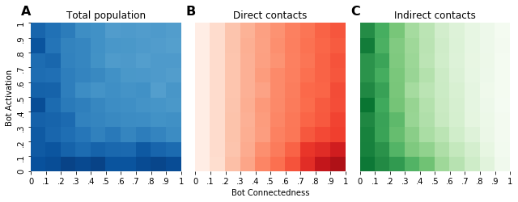

```python
fig = plt.figure(figsize=[9,3.5])

# TOTAL ---------------------------------------------
ax1 = plt.subplot(131)
ax1.set_title("Total population")
sns.heatmap(hg_avg_total, cbar=False,
            color='white', cmap='Blues', vmin=0, vmax=1)
plt.xticks([i for i in range(11)],
           ['0','.1','.2','.3','.4','.5','.6','.7','.8','.9','1'])
plt.yticks([i for i in range(11)],
           ['0','.1','.2','.3','.4','.5','.6','.7','.8','.9','1'])
plt.ylabel('Bot Activation')
plt.gca().invert_yaxis()

# FIRST DEGREE --------------------------------------
ax2 = plt.subplot(132)
ax2.set_title("Direct contacts")
sns.heatmap(hg_avg_first, cbar=False,
            color='white', cmap='Reds', vmin=0, vmax=1)
plt.xticks([i for i in range(11)],
           ['0','.1','.2','.3','.4','.5','.6','.7','.8','.9','1'])
plt.yticks([],[])
plt.xlabel('Bot Connectedness')
plt.gca().invert_yaxis()

# SECOND DEGREE -------------------------------------
ax3 = plt.subplot(133)
ax3.set_title("Indirect contacts")
sns.heatmap(hg_avg_second, cbar=False,
            color='white', cmap='Greens', vmin=0, vmax=1)
plt.xticks([i for i in range(11)],
           ['0','.1','.2','.3','.4','.5','.6','.7','.8','.9','1'])
plt.yticks([],[])
plt.gca().invert_yaxis()


plt.tight_layout()

ax1.text(0, 1.12, "A", transform=ax1.transAxes, fontsize=16, fontweight='bold', va='top', ha='right')
ax2.text(0, 1.12, "B", transform=ax2.transAxes, fontsize=16, fontweight='bold', va='top', ha='right')
ax3.text(0, 1.12, "C", transform=ax3.transAxes, fontsize=16, fontweight='bold', va='top', ha='right')



plt.show()

fig.savefig('plots/heatmap.png',dpi=300,bbox_inches='tight')
```

### 2.3 Labeled heatmaps SUPPLEMENTARY

These larger heatmaps include (1) the value of the cell as a label, and (2) the variance associated with each cell as a separate heatmap.

#### 2.3.1 Total population

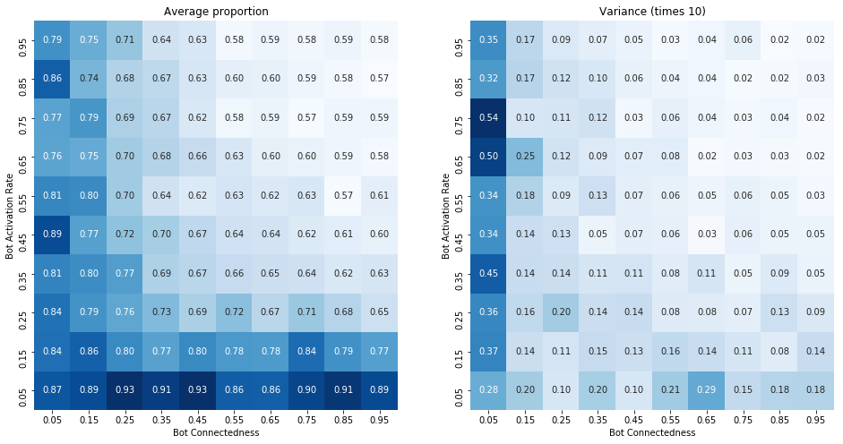

```python
# heatmap
fig = plt.figure(figsize=[16,8])

ax1 = plt.subplot(121)
ax1.set_title("Average proportion")
sns.heatmap(hg_avg_total, annot=hg_avg_total, fmt='.2f', cbar=False, color='white', cmap='Blues')
plt.xticks([i+.5 for i in range(len(hg_avg_total[0]))], [round(i,2) for i in np.unique(results['BotConnectedness'])])
plt.xlabel('Bot Connectedness')
plt.yticks([i+.5 for i in range(len(hg_avg_total))], [round(i,2) for i in np.unique(results['BotActivationRate'])])
plt.ylabel('Bot Activation Rate')
plt.gca().invert_yaxis()

ax2 = plt.subplot(122)
ax2.set_title("Variance (times 10)")
sns.heatmap(hg_var_total, annot=hg_var_total*10, fmt='.2f', cbar=False, color='white', cmap='Blues')
plt.xticks([i+.5 for i in range(len(hg_var_total[0]))], [round(i,2) for i in np.unique(results['BotConnectedness'])])
plt.xlabel('Bot Connectedness')
plt.yticks([i+.5 for i in range(len(hg_var_total))], [round(i,2) for i in np.unique(results['BotActivationRate'])])
plt.ylabel('Bot Activation Rate')
plt.gca().invert_yaxis()

plt.show()

fig.savefig('plots/heatmap_total.png',dpi=300,bbox_inches='tight')
```

#### 2.3.2 Direct contacts

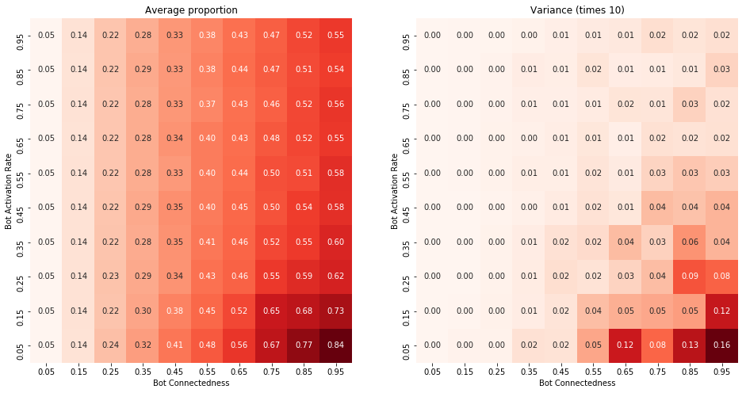

```python
# heatmap
fig = plt.figure(figsize=[16,8])

ax1 = plt.subplot(121)
ax1.set_title("Average proportion")
sns.heatmap(hg_avg_first, annot=hg_avg_first, fmt='.2f', cbar=False, color='white', cmap='Reds')
plt.xticks([i+.5 for i in range(len(hg_avg_first[0]))], [round(i,2) for i in np.unique(results['BotConnectedness'])])
plt.xlabel('Bot Connectedness')
plt.yticks([i+.5 for i in range(len(hg_avg_first))], [round(i,2) for i in np.unique(results['BotActivationRate'])])
plt.ylabel('Bot Activation Rate')
plt.gca().invert_yaxis()

ax2 = plt.subplot(122)
ax2.set_title("Variance (times 10)")
sns.heatmap(hg_var_first, annot=hg_var_first*10, fmt='.2f', cbar=False, color='white', cmap='Reds')
plt.xticks([i+.5 for i in range(len(hg_var_first[0]))], [round(i,2) for i in np.unique(results['BotConnectedness'])])
plt.xlabel('Bot Connectedness')
plt.yticks([i+.5 for i in range(len(hg_var_first))], [round(i,2) for i in np.unique(results['BotActivationRate'])])
plt.ylabel('Bot Activation Rate')
plt.gca().invert_yaxis()

plt.show()

fig.savefig('plots/heatmap_direct.png',dpi=300,bbox_inches='tight')
```

#### 2.3.3 Indirect contacts

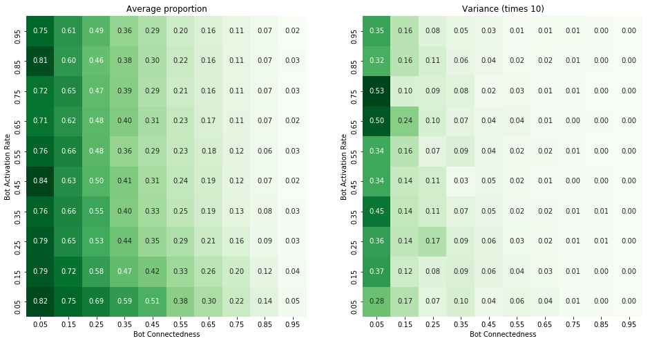

```python
# heatmap
fig = plt.figure(figsize=[16,8])

ax1 = plt.subplot(121)
ax1.set_title("Average proportion")
sns.heatmap(hg_avg_second, annot=hg_avg_second, fmt='.2f', cbar=False, color='white', cmap='Greens')
plt.xticks([i+.5 for i in range(len(hg_avg_second[0]))], [round(i,2) for i in np.unique(results['BotConnectedness'])])
plt.xlabel('Bot Connectedness')
plt.yticks([i+.5 for i in range(len(hg_avg_second))], [round(i,2) for i in np.unique(results['BotActivationRate'])])
plt.ylabel('Bot Activation Rate')
plt.gca().invert_yaxis()

ax2 = plt.subplot(122)
ax2.set_title("Variance (times 10)")
sns.heatmap(hg_var_second, annot=hg_var_second*10, fmt='.2f', cbar=False, color='white', cmap='Greens')
plt.xticks([i+.5 for i in range(len(hg_var_second[0]))], [round(i,2) for i in np.unique(results['BotConnectedness'])])
plt.xlabel('Bot Connectedness')
plt.yticks([i+.5 for i in range(len(hg_var_second))], [round(i,2) for i in np.unique(results['BotActivationRate'])])
plt.ylabel('Bot Activation Rate')
plt.gca().invert_yaxis()

plt.show()

fig.savefig('plots/heatmap_direct.png',dpi=300,bbox_inches='tight')
```

## 3. Statistical models

```python
col_names = ["Seed","BotConnectedness","BotActivationRate","N","Ticks",
             "DiffTotal","NagentsL1","DiffAgentsL1","NagentsL2","DiffAgentsL2"]

results = pd.read_csv('data/exp_1_full_range.csv', names=col_names, header=None)

# normalize proportions
results.loc[:, 'DiffTotal'] = (results.loc[:, 'DiffTotal']-1) / 144
results.loc[:, 'DiffAgentsL1'] = results.loc[:, 'DiffAgentsL1'] / 144
results.loc[:, 'DiffAgentsL2'] = results.loc[:, 'DiffAgentsL2'] / 144
```

```python
results['BotConnectedness_2'] = results['BotConnectedness'] * results['BotConnectedness']
results['BotActivationRate_2'] = results['BotActivationRate'] * results['BotActivationRate']
results['BotConnectedness_3'] = results['BotConnectedness'] * results['BotConnectedness'] * results['BotConnectedness']
results['BotActivationRate_3'] = results['BotActivationRate'] * results['BotActivationRate'] * results['BotActivationRate']
results['ConnectXActive'] = results['BotActivationRate'] * results['BotConnectedness']
```

### [Model 1] only linear effects

```python
X = results[["BotConnectedness","BotActivationRate"]]
y = results["DiffTotal"]
X = sm.add_constant(X) # adds intercept

model = sm.OLS(y, X).fit()
predictions = model.predict(X)

# Print out the statistics
model.summary()
```

OLS Regression Results

| Dep. Variable: | DiffTotal | R-squared: | 0.335 |
| --- | --- | --- | --- |
| Model: | OLS | Adj. R-squared: | 0.334 |
| Method: | Least Squares | F-statistic: | 628.2 |
| Date: | Wed, 29 Apr 2020 | Prob (F-statistic): | 1.02e-221 |
| Time: | 19:48:16 | Log-Likelihood: | 1706.5 |
| No. Observations: | 2500 | AIC: | -3407. |
| Df Residuals: | 2497 | BIC: | -3389. |
| Df Model: | 2 |  |  |
| Covariance Type: | nonrobust |  |  |

|  | coef | std err | t | P>\|t\| | [0.025 | 0.975] |
| --- | --- | --- | --- | --- | --- | --- |
| const | 0.9182 | 0.007 | 141.225 | 0.000 | 0.905 | 0.931 |
| BotConnectedness | -0.1911 | 0.009 | -22.428 | 0.000 | -0.208 | -0.174 |
| BotActivationRate | -0.2338 | 0.009 | -27.448 | 0.000 | -0.251 | -0.217 |

| Omnibus: | 58.948 | Durbin-Watson: | 1.645 |
| --- | --- | --- | --- |
| Prob(Omnibus): | 0.000 | Jarque-Bera (JB): | 87.098 |
| Skew: | -0.245 | Prob(JB): | 1.22e-19 |
| Kurtosis: | 3.773 | Cond. No. | 5.32 |

Warnings:  
[1] Standard Errors assume that the covariance matrix of the errors is correctly specified.

### [Model 2] linear and quadratic terms

```python
X = results[["BotConnectedness","BotActivationRate",'BotConnectedness_2','BotActivationRate_2']]
y = results["DiffTotal"]
X = sm.add_constant(X) # adds intercept

model = sm.OLS(y, X).fit()
predictions = model.predict(X)

# Print out the statistics
model.summary()
```

OLS Regression Results

| Dep. Variable: | DiffTotal | R-squared: | 0.413 |
| --- | --- | --- | --- |
| Model: | OLS | Adj. R-squared: | 0.412 |
| Method: | Least Squares | F-statistic: | 439.3 |
| Date: | Wed, 29 Apr 2020 | Prob (F-statistic): | 7.52e-287 |
| Time: | 19:48:16 | Log-Likelihood: | 1863.4 |
| No. Observations: | 2500 | AIC: | -3717. |
| Df Residuals: | 2495 | BIC: | -3688. |
| Df Model: | 4 |  |  |
| Covariance Type: | nonrobust |  |  |

|  | coef | std err | t | P>\|t\| | [0.025 | 0.975] |
| --- | --- | --- | --- | --- | --- | --- |
| const | 1.0502 | 0.010 | 108.617 | 0.000 | 1.031 | 1.069 |
| BotConnectedness | -0.4759 | 0.033 | -14.584 | 0.000 | -0.540 | -0.412 |
| BotActivationRate | -0.7367 | 0.033 | -22.575 | 0.000 | -0.801 | -0.673 |
| BotConnectedness_2 | 0.2849 | 0.032 | 9.005 | 0.000 | 0.223 | 0.347 |
| BotActivationRate_2 | 0.5029 | 0.032 | 15.896 | 0.000 | 0.441 | 0.565 |

| Omnibus: | 238.507 | Durbin-Watson: | 1.866 |
| --- | --- | --- | --- |
| Prob(Omnibus): | 0.000 | Jarque-Bera (JB): | 438.456 |
| Skew: | -0.645 | Prob(JB): | 6.17e-96 |
| Kurtosis: | 4.595 | Cond. No. | 26.7 |

Warnings:  
[1] Standard Errors assume that the covariance matrix of the errors is correctly specified.

### [Model 3] linear + quadratic + interaction

```python
X = results[["BotConnectedness","BotActivationRate",'BotConnectedness_2','BotActivationRate_2','ConnectXActive']]
y = results["DiffTotal"]
X = sm.add_constant(X) # adds intercept

model = sm.OLS(y, X).fit()
predictions = model.predict(X)

# Print out the statistics
model.summary()
```

OLS Regression Results

| Dep. Variable: | DiffTotal | R-squared: | 0.430 |
| --- | --- | --- | --- |
| Model: | OLS | Adj. R-squared: | 0.429 |
| Method: | Least Squares | F-statistic: | 376.9 |
| Date: | Wed, 29 Apr 2020 | Prob (F-statistic): | 1.50e-301 |
| Time: | 19:48:16 | Log-Likelihood: | 1900.5 |
| No. Observations: | 2500 | AIC: | -3789. |
| Df Residuals: | 2494 | BIC: | -3754. |
| Df Model: | 5 |  |  |
| Covariance Type: | nonrobust |  |  |

|  | coef | std err | t | P>\|t\| | [0.025 | 0.975] |
| --- | --- | --- | --- | --- | --- | --- |
| const | 0.9907 | 0.012 | 84.357 | 0.000 | 0.968 | 1.014 |
| BotConnectedness | -0.3569 | 0.035 | -10.207 | 0.000 | -0.425 | -0.288 |
| BotActivationRate | -0.6177 | 0.035 | -17.665 | 0.000 | -0.686 | -0.549 |
| BotConnectedness_2 | 0.2849 | 0.031 | 9.137 | 0.000 | 0.224 | 0.346 |
| BotActivationRate_2 | 0.5029 | 0.031 | 16.130 | 0.000 | 0.442 | 0.564 |
| ConnectXActive | -0.2380 | 0.027 | -8.668 | 0.000 | -0.292 | -0.184 |

| Omnibus: | 280.105 | Durbin-Watson: | 1.922 |
| --- | --- | --- | --- |
| Prob(Omnibus): | 0.000 | Jarque-Bera (JB): | 487.517 |
| Skew: | -0.756 | Prob(JB): | 1.37e-106 |
| Kurtosis: | 4.547 | Cond. No. | 29.7 |

Warnings:  
[1] Standard Errors assume that the covariance matrix of the errors is correctly specified.

### [Model 4] linear + quadratic + cubed + interaction SUPPLEMENTARY

```python
X = results[["BotConnectedness","BotActivationRate",'BotConnectedness_2','BotActivationRate_2',
             'BotConnectedness_3','BotActivationRate_3','ConnectXActive']]
y = results["DiffTotal"]
X = sm.add_constant(X) # adds intercept

model = sm.OLS(y, X).fit()
predictions = model.predict(X)

# Print out the statistics
model.summary()
```

OLS Regression Results

| Dep. Variable: | DiffTotal | R-squared: | 0.440 |
| --- | --- | --- | --- |
| Model: | OLS | Adj. R-squared: | 0.438 |
| Method: | Least Squares | F-statistic: | 279.6 |
| Date: | Wed, 29 Apr 2020 | Prob (F-statistic): | 4.24e-308 |
| Time: | 19:48:16 | Log-Likelihood: | 1921.7 |
| No. Observations: | 2500 | AIC: | -3827. |
| Df Residuals: | 2492 | BIC: | -3781. |
| Df Model: | 7 |  |  |
| Covariance Type: | nonrobust |  |  |

|  | coef | std err | t | P>\|t\| | [0.025 | 0.975] |
| --- | --- | --- | --- | --- | --- | --- |
| const | 1.0426 | 0.015 | 69.773 | 0.000 | 1.013 | 1.072 |
| BotConnectedness | -0.4734 | 0.085 | -5.595 | 0.000 | -0.639 | -0.307 |
| BotActivationRate | -1.1071 | 0.085 | -13.085 | 0.000 | -1.273 | -0.941 |
| BotConnectedness_2 | 0.5744 | 0.194 | 2.956 | 0.003 | 0.193 | 0.955 |
| BotActivationRate_2 | 1.7193 | 0.194 | 8.849 | 0.000 | 1.338 | 2.100 |
| BotConnectedness_3 | -0.1930 | 0.128 | -1.509 | 0.131 | -0.444 | 0.058 |
| BotActivationRate_3 | -0.8109 | 0.128 | -6.342 | 0.000 | -1.062 | -0.560 |
| ConnectXActive | -0.2380 | 0.027 | -8.738 | 0.000 | -0.291 | -0.185 |

| Omnibus: | 325.787 | Durbin-Watson: | 1.950 |
| --- | --- | --- | --- |
| Prob(Omnibus): | 0.000 | Jarque-Bera (JB): | 629.628 |
| Skew: | -0.817 | Prob(JB): | 1.90e-137 |
| Kurtosis: | 4.837 | Cond. No. | 156. |

Warnings:  
[1] Standard Errors assume that the covariance matrix of the errors is correctly specified.

## 4. Sensitivity analyses

### 4.1 One-to-many communication

```python
col_names = ["Ticks", "N", "BotActivationRate", "DiffTotal", "NagentsL2",
             "Regime", "DiffAgentsL2", "Seed", "NagentsL1", "DiffAgentsL1",
             "BotConnectedness"]
results = pd.read_csv('data/exp_4_onetomany.csv', names=col_names, header=None)

results.loc[:, 'DiffTotal'] = results.loc[:, 'DiffTotal'] / results.loc[:, 'N']
results.loc[:, 'DiffAgentsL1'] = results.loc[:, 'DiffAgentsL1'] / results.loc[:, 'NagentsL1']
results.loc[:, 'DiffAgentsL2'] = results.loc[:, 'DiffAgentsL2'] / results.loc[:, 'NagentsL2']

results = results.sort_values(by='Regime', ascending=False)
```

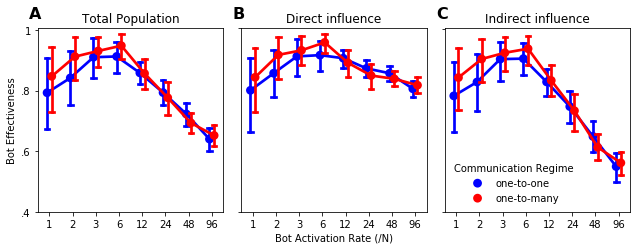

```python
fig = plt.figure(figsize=[9,3.5])

# TOTAL POPULATION
ax1 = plt.subplot(131)
ax1.text(0.02, 1.12, "A", transform=ax1.transAxes,
         fontsize=16, fontweight='bold', va='top', ha='right')
ax1 = sns.pointplot(x="BotActivationRate", y="DiffTotal", hue="Regime",
                   capsize=.2, dodge=.2, palette=['b','r'], ci=95,
                   data=results)
plt.xticks([0,1,2,3,4,5,6,7],
           [i for i in [1,2,3,6,12,24,48,96]])
plt.yticks([.4,.6,.8,1],['.4','.6','.8','1'])
plt.title('Total Population')
plt.ylabel('Bot Effectiveness')
plt.xlabel('')
ax1.get_legend().remove()


# DIRECT INFLUENCE
ax2 = plt.subplot(132)
ax2.text(0.02, 1.12, "B", transform=ax2.transAxes,
         fontsize=16, fontweight='bold', va='top', ha='right')
ax2 = sns.pointplot(x="BotActivationRate", y="DiffAgentsL1", hue="Regime",
                   capsize=.2, dodge=.2, palette=['b','r'], ci=95,
                   data=results)
plt.xticks([0,1,2,3,4,5,6,7],
           [i for i in [1,2,3,6,12,24,48,96]])
plt.yticks([.4,1],['',''])
plt.title('Direct influence')
plt.ylabel('')
plt.xlabel('Bot Activation Rate (/N)')
ax2.get_legend().remove()


# INDIRECT INFLUENCE
ax3 = plt.subplot(133)
ax3.text(0.02, 1.12, "C", transform=ax3.transAxes,
         fontsize=16, fontweight='bold', va='top', ha='right')
ax3 = sns.pointplot(x="BotActivationRate", y="DiffAgentsL2", hue="Regime",
                   capsize=.2, dodge=.2, palette=['b','r'], ci=95,
                   data=results)
plt.xticks([0,1,2,3,4,5,6,7],
           [i for i in [1,2,3,6,12,24,48,96]])
plt.yticks([.4,1],['',''])
plt.title('Indirect influence')
plt.ylabel('')
plt.xlabel('')
ax3.legend(title='Communication Regime',frameon=False)


plt.tight_layout()
plt.show()
fig.savefig('plots/sensitivity_onetomany.png',dpi=300,bbox_inches='tight')
```

### 4.2 Filter bubbles and echo chambers: how homophily affects the bot’s effectiveness

```python
col_names = ["BotConnectedness", "RewiringProportion", "Transitivity", "NagentsL1",
             "BotActivationRate", "DiffTotal", "N", "DiffAgentsL1", "Ticks",
             "NagentsL2", "DiffAgentsL2", "Seed"]
results = pd.read_csv('data/exp_5_rewiring.csv', names=col_names, header=None)

#results.loc[:, 'DiffAgentsL2'] += results.loc[:, 'DiffAgentsL3']
#results.loc[:, 'NagentsL2'] += results.loc[:, 'NagentsL3']

results.loc[:, 'DiffTotal'] = results.loc[:, 'DiffTotal'] / results.loc[:, 'N']
results.loc[:, 'DiffAgentsL1'] = results.loc[:, 'DiffAgentsL1'] / results.loc[:, 'NagentsL1']
results.loc[:, 'DiffAgentsL2'] = results.loc[:, 'DiffAgentsL2'] / results.loc[:, 'NagentsL2']

results.loc[:, 'BotActivationRate'] = results.loc[:, 'BotActivationRate'].replace(48/144,'high (1/3)')
results.loc[:, 'BotActivationRate'] = results.loc[:, 'BotActivationRate'].replace(0.04166666666666666,'low (1/24)')
results = results.sort_values(by='BotActivationRate', ascending=True)
```

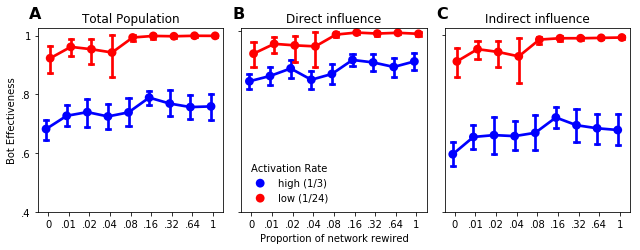

```python
fig = plt.figure(figsize=[9,3.5])

# TOTAL POPULATION
ax1 = plt.subplot(131)
ax1.text(0.02, 1.12, "A", transform=ax1.transAxes,
         fontsize=16, fontweight='bold', va='top', ha='right')
ax1 = sns.pointplot(x="RewiringProportion", y="DiffTotal", hue="BotActivationRate",
                   capsize=.2, dodge=.2, palette=['b','r'], ci=95,
                   data=results)
plt.xticks([i for i in range(9)],
           ['0','.01','.02','.04','.08','.16','.32','.64','1'])
plt.yticks([.4,.6,.8,1],['.4','.6','.8','1'])
plt.title('Total Population')
plt.ylabel('Bot Effectiveness')
plt.xlabel('')
ax1.get_legend().remove()


# DIRECT INFLUENCE
ax2 = plt.subplot(132)
ax2.text(0.02, 1.12, "B", transform=ax2.transAxes,
         fontsize=16, fontweight='bold', va='top', ha='right')
ax2 = sns.pointplot(x="RewiringProportion", y="DiffAgentsL1", hue="BotActivationRate",
                   capsize=.2, dodge=.2, palette=['b','r'], ci=95,
                   data=results)
plt.xticks([i for i in range(9)],
           ['0','.01','.02','.04','.08','.16','.32','.64','1'])
plt.yticks([.4,1],['',''])
plt.title('Direct influence')
plt.ylabel('')
plt.xlabel('Proportion of network rewired')
ax2.legend(title='Activation Rate',frameon=False)


# INDIRECT INFLUENCE
ax3 = plt.subplot(133)
ax3.text(0.02, 1.12, "C", transform=ax3.transAxes,
         fontsize=16, fontweight='bold', va='top', ha='right')
ax3 = sns.pointplot(x="RewiringProportion", y="DiffAgentsL2", hue="BotActivationRate",
                   capsize=.2, dodge=.2, palette=['b','r'], ci=95,
                   data=results)
plt.xticks([i for i in range(9)],
           ['0','.01','.02','.04','.08','.16','.32','.64','1'])
plt.yticks([.4,1],['',''])
plt.title('Indirect influence')
plt.ylabel('')
plt.xlabel('')
ax3.get_legend().remove()


plt.tight_layout()
plt.show()
fig.savefig('plots/sensitivity_rewiring.png',dpi=300,bbox_inches='tight')
```

### 4.3 Aligning with Axelrod: dynamics on the wrapped lattice

```python
col_names = ["BotConnectedness", "NagentsL1", "NagentsL2", "Neighborhood",
             "Ticks", "BotActivationRate", "DiffAgentsL1", "Seed", "DiffTotal",
             "DiffAgentsL2", "N"]

results = pd.read_csv('data/exp_3_torus.csv', names=col_names, header=None)

#results.loc[:, 'DiffAgentsL2'] += results.loc[:, 'DiffAgentsL3']
#results.loc[:, 'NagentsL2'] += results.loc[:, 'NagentsL3']

results.loc[:, 'DiffTotal'] = results.loc[:, 'DiffTotal'] / results.loc[:, 'N']
results.loc[:, 'DiffAgentsL1'] = results.loc[:, 'DiffAgentsL1'] / results.loc[:, 'NagentsL1']
results.loc[:, 'DiffAgentsL2'] = results.loc[:, 'DiffAgentsL2'] / results.loc[:, 'NagentsL2']

results.loc[:, 'Neighborhood'] = results.loc[:, 'Neighborhood'].replace('von_neumann','Von Neumann')
results.loc[:, 'Neighborhood'] = results.loc[:, 'Neighborhood'].replace('moore','Moore')
results = results.sort_values(by='Neighborhood', ascending=True)
```

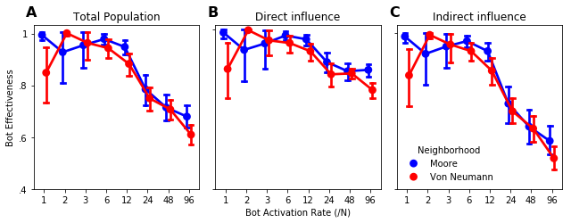

```python
fig = plt.figure(figsize=[9,3.5])

# TOTAL POPULATION
ax1 = plt.subplot(131)
ax1.text(0.02, 1.12, "A", transform=ax1.transAxes,
         fontsize=16, fontweight='bold', va='top', ha='right')
ax1 = sns.pointplot(x="BotActivationRate", y="DiffTotal", hue="Neighborhood",
                   capsize=.2, dodge=.2, palette=['b','r'], ci=95,
                   data=results)
plt.xticks([i for i in range(8)],
           [1, 2, 3, 6, 12, 24, 48, 96])
plt.yticks([.4,.6,.8,1],['.4','.6','.8','1'])
plt.title('Total Population')
plt.ylabel('Bot Effectiveness')
plt.xlabel('')
ax1.get_legend().remove()


# DIRECT INFLUENCE
ax2 = plt.subplot(132)
ax2.text(0.02, 1.12, "B", transform=ax2.transAxes,
         fontsize=16, fontweight='bold', va='top', ha='right')
ax2 = sns.pointplot(x="BotActivationRate", y="DiffAgentsL1", hue="Neighborhood",
                   capsize=.2, dodge=.2, palette=['b','r'], ci=95,
                   data=results)
plt.xticks([i for i in range(8)],
           [1, 2, 3, 6, 12, 24, 48, 96])
plt.yticks([.4,1],['',''])
plt.title('Direct influence')
plt.ylabel('')
plt.xlabel('Bot Activation Rate (/N)')
ax2.get_legend().remove()


# INDIRECT INFLUENCE
ax3 = plt.subplot(133)
ax3.text(0.02, 1.12, "C", transform=ax3.transAxes,
         fontsize=16, fontweight='bold', va='top', ha='right')
ax3 = sns.pointplot(x="BotActivationRate", y="DiffAgentsL2", hue="Neighborhood",
                   capsize=.2, dodge=.2, palette=['b','r'], ci=95,
                   data=results)
plt.xticks([i for i in range(8)],
           [1, 2, 3, 6, 12, 24, 48, 96])
plt.yticks([.4,1],['',''])
plt.title('Indirect influence')
plt.ylabel('')
plt.xlabel('')
ax3.legend(title='Neighborhood',frameon=False)


plt.tight_layout()
plt.show()
fig.savefig('plots/sensitivity_torus.png',dpi=300,bbox_inches='tight')
```

### 4.4 Directed graphs

The directed spatial random graph is constructed with the following function:

```python
def directed_spatial_random_graph(num_agents=144, degree=12, proximity_weight=1, return_positions=False, seed=None):
    np.random.seed(seed)

    if type(degree) == int:
        degree_seq = [degree for i in range(num_agents)]
    elif type(degree) == list:
        if len(degree) == num_agents:
            degree_seq = degree
        else:
            raise ValueError('\'degree\' is not of length \'num_agents\'')
    else:
        raise ValueError('\'degree\' should be an integer or a list with length \'num_agents\'')
    if any([i >= num_agents for i in degree_seq]):
        degree_seq = [i if i < num_agents else (num_agents-1) for i in degree_seq]

    xypos = np.column_stack((np.random.uniform(0, 100, num_agents), np.random.uniform(0, 100, num_agents)))

    def dist(posA, posB, proximity_weight):  # returns the probability as a function of distance
        return np.exp(-proximity_weight * np.sqrt(np.sum((posA - posB) ** 2)))

    distmatrix = np.zeros((num_agents, num_agents))

    for i in range(num_agents):
        for j in range(num_agents):
            if i == j:
                distmatrix[i, j] = 0  # later turned to 0!
            else:
                distmatrix[i, j] = dist(xypos[i], xypos[j],proximity_weight)

    # pick min_neighbors neighbors with a probability equal to their relative euclidean distance
    edgelist = []
    degreelist = []

    for i in range(num_agents):
        distp = distmatrix[i]
        distp /= distp.sum()  # normalizing the probabilities

        if degreelist.count(i) < degree_seq[i]:
            try:
                alters = np.random.choice(num_agents, degree_seq[i], replace=False, p=distp)
                for j in alters:
                    edgelist.append([i, j])
                    degreelist.append(i)
                    #degreelist.append(j)
            except(ValueError):
                print(
                    "Please pick a lower value for the proximity weight. This value creates too many probability values of 0")

    G = nx.DiGraph()
    G.add_nodes_from([i for i in range(num_agents)])
    G.add_edges_from(edgelist)

    if return_positions:
        return G, xypos
    else:
        return G
```

```python
def simulation_run(network,
                   bot_connectedness=.25,
                   bot_activation_rate=.25,
                   N=144,
                   K=12,
                   P=0,
                   return_activity_monitor=True,
                   return_graph=False,
                   max_ticks=100000,
                   seed=None):
    """
    This function
        1. Creates the Axelrod model as a NetworkX graph object with a bot
        2. Executes similarity biased influence between
            a. the BOT and a randomly selected network neighbor (with p = bot_activation_rate)
            b. two randomly selected network neighbors (with p = 1-bot_activation_rate)
        3. Returns graph object when no further influence is possible (or after 100,000 ticks)
    """

    ## PHASE 1) INITIALIZATION

    # seed the run for replicability
    random.seed(seed)

    # generate the NetworkX graph object and intialize with F random categorical features with Q traits
    G = network #directed_spatial_random_graph()
    ds.initialize_attributes(G, realization="random_categorical", num_features=3, num_traits=3)

    # add the bot to the graph
    agentlist = list(G.nodes())
    G.add_node("bot")
    G.nodes["bot"]["f01"] = 99    # Unique bot trait, used to track the bot's effectiveness
    G.nodes["bot"]["f02"] = 0
    G.nodes["bot"]["f03"] = 0

    # connect the bot to a proportion 'bot_connectedness' of the graph
    friends_of_bot = random.sample(agentlist, int(bot_connectedness * N))
    for j in friends_of_bot:
        G.add_edge("bot",j)

    # calculate the dissimilarity on all edges
    calculator = ds.dissimilarity_calculator.select_calculator("hamming")
    calculator.calculate_dissimilarity_networkwide(G)

    # store the indices of direct and indirect contacts of the bot
    shortest_paths = nx.shortest_path_length(G,'bot')
    agents_l1 = [key for key, val in shortest_paths.items() if val == 1]
    agents_l2 = [key for key, val in shortest_paths.items() if val >= 2]

    # initialize ticks, stop variable, and tickwise dictionaries for output
    ticks = 0
    stop = False
    bot_trait_count = [dict(count_l1=len(agents_l1),
                            count_l2=len(agents_l2))]
    activity_monitor = dict(success=[],
                            i_is_bot=[])

    ## PHASE 2) SIMULATION

    while(not stop):
        ticks += 1

        # choose sending agent
        if random.random() > bot_activation_rate:
            agent_i = ds.select_focal_agent(G,"random",agentlist=agentlist)
            activity_monitor['i_is_bot'].append(False)
        else:
            agent_i = "bot"
            activity_monitor['i_is_bot'].append(True)

        # choose receiving agent
        agent_j = ["bot"]
        while agent_j == ["bot"]:
            agent_j = [(random.choice([neighbor for neighbor in G[agent_i]]))]

        # exert influence and store whether influence was successful
        activity_monitor['success'].append(
            ds.influence_sim.spread_influence(G,"axelrod",agent_i,agent_j,"one-to-one",calculator)
        )

        # store the diffusion of the unique bot trait among first and second (or more) degree contacts
        bot_trait_count.append({'count_l1': len([1 for i in agents_l1 if G.nodes[i]['f01']==99]) / len(agents_l1),
                                'count_l2': len([1 for i in agents_l2 if G.nodes[i]['f01']==99]) / len(agents_l2)})

        # stop the execution if condition is true
        if(not any([True for i,j,d in G.edges.data('dist') if 0.1 < d < .9])
          or ticks > max_ticks):
            if(return_graph):
                return G
            if(return_activity_monitor):
                return bot_trait_count, activity_monitor
            else:
                return bot_trait_count
            stop = True
```

```python
# function to generate the network figures for spatial random graphs
def gen_srg_fig(G, xypos):
    pos = {'bot': [0,0]}
    pos.update(dict(zip([i for i in range(len(G.nodes()))], xypos)))

    nodecol = ['r' if G.nodes[i]['f01'] == 99 else 'b' for i in G.nodes()]
    bin_col = plt.cm.get_cmap('binary', 4)
    edgecol = [bin_col(1 - G.edges[i]['dist']) for i in G.edges()]

    bot_contacts = []
    for i, j in G.edges():
        if i == 'bot':
            bot_contacts.append(j)
        if j == 'bot':
            bot_contacts.append(i)



    Gcopy = G.copy()
    #Gcopy.remove_edges_from([i for i in G.edges() if G.edges[i]['dist'] == 1])
    Gcopy = Gcopy.subgraph([i for i in Gcopy.nodes() if i != 'bot'])

    nx.draw_networkx_edges(Gcopy, pos=pos, edge_color=edgecol)
    nx.draw_networkx_nodes(Gcopy.subgraph([i for i in G.nodes() if i not in bot_contacts]),
                           pos=pos, node_shape='o', node_size=75, node_color=nodecol)
    nx.draw_networkx_nodes(Gcopy.subgraph(bot_contacts),
                           pos=pos, node_shape='^', node_size=75, node_color=nodecol)
```

With the functions defined above, we can create spatial random graphs, run a single simulation run with them, and plot the obtained graph. Nodes linked to the bot are shown as triangles.

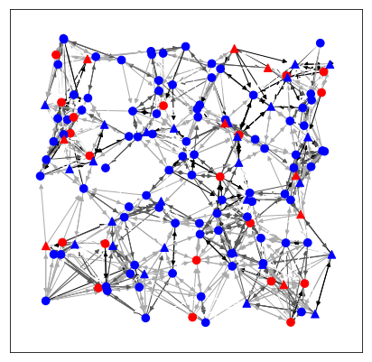

```python
plt.figure(figsize=[7,7])
G, xypos = directed_spatial_random_graph(degree=12,
                                         return_positions = True,
                                         seed=23652)
G = simulation_run(network=G,
                   return_graph=True,
                   seed = 23652,
                   max_ticks = 1000)
gen_srg_fig(G, xypos)
plt.show()
```

We ran an experiment outside of this notebook, that used the functions printed above.

```python
col_names = ["Seed","BotConnectedness","BotActivationRate","N","Ticks",
             "DiffTotal","NagentsL1","DiffAgentsL1","NagentsL2","DiffAgentsL2",
             "ProximityWeight","Transitivity","Reciprocity"]

results = pd.read_csv('data/directed_graphs_simple.csv', names=col_names, header=None)
```

```python
results.loc[:, 'DiffTotal'] = (results.loc[:, 'DiffTotal'] - 1) / results.loc[:, 'N']
results.loc[:, 'DiffAgentsL1'] = results.loc[:, 'DiffAgentsL1'] / results.loc[:, 'NagentsL1']
results.loc[:, 'DiffAgentsL2'] = results.loc[:, 'DiffAgentsL2'] / results.loc[:, 'NagentsL2']
```

```python
df = results.melt(id_vars=["BotConnectedness","BotActivationRate","Transitivity","Reciprocity"],
             value_vars=['DiffTotal','DiffAgentsL1','DiffAgentsL2'],
             value_name="Bot Effectiveness")
```

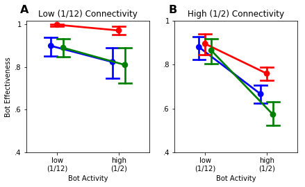

```python
fig = plt.figure(figsize=[7,3.5])

# TOTAL POPULATION
ax1 = plt.subplot(121)
ax1.text(0.02, 1.12, "A", transform=ax1.transAxes,
         fontsize=16, fontweight='bold', va='top', ha='right')
ax1 = sns.pointplot(x="BotActivationRate", y="Bot Effectiveness", hue="variable",
                   capsize=.2, dodge=.2, palette=['b','r','g'], ci=95,
                   data=df.loc[df['BotConnectedness'] < .1,])
plt.xticks([0,1], ['low\n(1/12)','high\n(1/2)'])
plt.yticks([.4,.6,.8,1],['.4','.6','.8','1'])
plt.title('Low (1/12) Connectivity')
plt.ylabel('Bot Effectiveness')
plt.xlabel('Bot Activity')
ax1.get_legend().remove()

# TOTAL POPULATION
ax2 = plt.subplot(122)
ax2.text(0.02, 1.12, "B", transform=ax2.transAxes,
         fontsize=16, fontweight='bold', va='top', ha='right')
ax2 = sns.pointplot(x="BotActivationRate", y="Bot Effectiveness", hue="variable",
                   capsize=.2, dodge=.2, palette=['b','r','g'], ci=95,
                   data=df.loc[df['BotConnectedness'] > .1,])
plt.xticks([0,1], ['low\n(1/12)','high\n(1/2)'])
plt.yticks([.4,.6,.8,1],['.4','.6','.8','1'])
plt.title('High (1/2) Connectivity')
plt.ylabel('')
plt.xlabel('Bot Activity')
ax2.get_legend().remove()

plt.show()
fig.savefig('plots/sensitivity_directed.png',dpi=300,bbox_inches='tight')
```

### 4.5 Varying the degree distribution

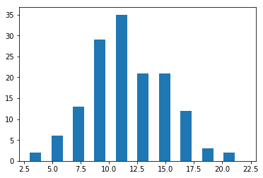

```python
#plt.hist((np.random.poisson(12,144) * np.random.poisson(12,144)) / 12)
np.random.seed(56)
plt.hist(np.random.poisson(12,144),width=1)
plt.show()
```

```python
G = directed_spatial_random_graph(num_agents=144,
                              degree=[round(i) for i in (np.random.poisson(12,144) * np.random.poisson(12,144)) / 12],
                              proximity_weight=1,
                              return_positions=False,
                              seed=None)
```

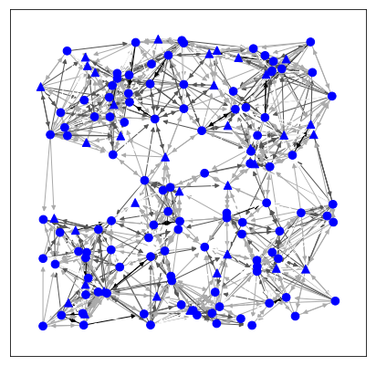

```python
plt.figure(figsize=[7,7])
G, xypos = directed_spatial_random_graph(degree=[round(i) for i in (np.random.poisson(12,144) * np.random.poisson(12,144)) / 12],
                                         return_positions = True)
G = simulation_run(network=G,
                   return_graph=True,
                   seed = 123,
                   max_ticks = 0)
gen_srg_fig(G, xypos)
plt.show()
```

```python
col_names = ["Seed","BotConnectedness","BotActivationRate","N","Ticks",
             "DiffTotal","NagentsL1","DiffAgentsL1","NagentsL2","DiffAgentsL2",
             "ProximityWeight","Transitivity","Reciprocity","ConnectTo"]

results = pd.read_csv('data/unbalanced_degree.csv', names=col_names, header=None)
```

```python
results.loc[:, 'DiffTotal'] = (results.loc[:, 'DiffTotal'] - 1) / results.loc[:, 'N']
results.loc[:, 'DiffAgentsL1'] = results.loc[:, 'DiffAgentsL1'] / results.loc[:, 'NagentsL1']
results.loc[:, 'DiffAgentsL2'] = results.loc[:, 'DiffAgentsL2'] / results.loc[:, 'NagentsL2']
```

```python
df = results.melt(id_vars=["BotConnectedness","BotActivationRate","Transitivity","Reciprocity","ConnectTo"],
             value_vars=['DiffTotal','DiffAgentsL1','DiffAgentsL2'],
             value_name="Bot Effectiveness")
```

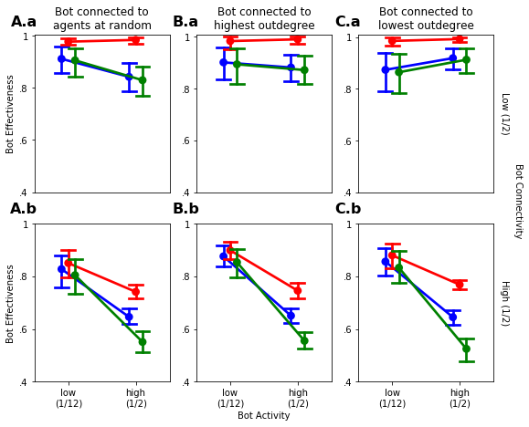

```python
fig = plt.figure(figsize=[9,7])
fig.tight_layout()

# RANDOM
ax1 = plt.subplot(231)
ax1.text(0.02, 1.12, "A.a", transform=ax1.transAxes,
         fontsize=16, fontweight='bold', va='top', ha='right')
ax1 = sns.pointplot(x="BotActivationRate", y="Bot Effectiveness", hue="variable",
                   capsize=.2, dodge=.2, palette=['b','r','g'], ci=95,
                   data=df.loc[(df['BotConnectedness'] < .1) & (df['ConnectTo'] == 'random') ,])
plt.xticks([], [])
plt.yticks([.4,.6,.8,1],['.4','.6','.8','1'])
plt.title('Bot connected to\nagents at random')
plt.ylabel('Bot Effectiveness')
plt.xlabel('')
ax1.get_legend().remove()

ax2 = plt.subplot(234)
ax2.text(0.02, 1.14, "A.b", transform=ax2.transAxes,
         fontsize=16, fontweight='bold', va='top', ha='right')
ax2 = sns.pointplot(x="BotActivationRate", y="Bot Effectiveness", hue="variable",
                   capsize=.2, dodge=.2, palette=['b','r','g'], ci=95,
                   data=df.loc[(df['BotConnectedness'] > .1) & (df['ConnectTo'] == 'random') ,])
plt.xticks([0,1], ['low\n(1/12)','high\n(1/2)'])
plt.yticks([.4,.6,.8,1],['.4','.6','.8','1'])
plt.title('')
plt.ylabel('Bot Effectiveness')
plt.xlabel('')
ax2.get_legend().remove()

# HIGHEST
ax3 = plt.subplot(232)
ax3.text(0.02, 1.12, "B.a", transform=ax3.transAxes,
         fontsize=16, fontweight='bold', va='top', ha='right')
ax3 = sns.pointplot(x="BotActivationRate", y="Bot Effectiveness", hue="variable",
                   capsize=.2, dodge=.2, palette=['b','r','g'], ci=95,
                   data=df.loc[(df['BotConnectedness'] < .1) & (df['ConnectTo'] == 'highest') ,])
plt.xticks([], [])
plt.yticks([.4,.6,.8,1],['.4','.6','.8','1'])
plt.title('Bot connected to\nhighest outdegree')
plt.ylabel('')
plt.xlabel('')
ax3.get_legend().remove()

ax4 = plt.subplot(235)
ax4.text(0.02, 1.14, "B.b", transform=ax4.transAxes,
         fontsize=16, fontweight='bold', va='top', ha='right')
ax4 = sns.pointplot(x="BotActivationRate", y="Bot Effectiveness", hue="variable",
                   capsize=.2, dodge=.2, palette=['b','r','g'], ci=95,
                   data=df.loc[(df['BotConnectedness'] > .1) & (df['ConnectTo'] == 'highest') ,])
plt.xticks([0,1], ['low\n(1/12)','high\n(1/2)'])
plt.yticks([.4,.6,.8,1],['.4','.6','.8','1'])
plt.title('')
plt.ylabel('')
plt.xlabel('Bot Activity')
ax4.get_legend().remove()

# LOWEST
ax5 = plt.subplot(233)
ax5.text(0.02, 1.12, "C.a", transform=ax5.transAxes,
         fontsize=16, fontweight='bold', va='top', ha='right')
ax5 = sns.pointplot(x="BotActivationRate", y="Bot Effectiveness", hue="variable",
                   capsize=.2, dodge=.2, palette=['b','r','g'], ci=95,
                   data=df.loc[(df['BotConnectedness'] < .1) & (df['ConnectTo'] == 'lowest') ,])
plt.xticks([], [])
plt.yticks([.4,.6,.8,1],['.4','.6','.8','1'])
plt.title('Bot connected to\nlowest outdegree')
plt.ylabel('')
plt.xlabel('')
ax5.get_legend().remove()

ax6 = plt.subplot(236)
ax6.text(0.02, 1.14, "C.b", transform=ax6.transAxes,
         fontsize=16, fontweight='bold', va='top', ha='right')
ax6 = sns.pointplot(x="BotActivationRate", y="Bot Effectiveness", hue="variable",
                   capsize=.2, dodge=.2, palette=['b','r','g'], ci=95,
                   data=df.loc[(df['BotConnectedness'] > .1) & (df['ConnectTo'] == 'lowest') ,])
plt.xticks([0,1], ['low\n(1/12)','high\n(1/2)'])
plt.yticks([.4,.6,.8,1],['.4','.6','.8','1'])
plt.title('')
plt.ylabel('')
plt.xlabel('')
ax6.get_legend().remove()


ax5.text(1.15, -0.05, "Bot Connectivity",
        rotation=-90, size=10,
        ha='left', va='center', transform = ax5.transAxes)
ax5.text(1.05, 0.5, "Low (1/2)",
        rotation=-90, size=10,
        ha='left', va='center', transform = ax5.transAxes)
ax6.text(1.05, 0.5, "High (1/2)",
        rotation=-90, size=10,
        ha='left', va='center', transform = ax6.transAxes)


plt.show()
fig.savefig('plots/sensitivity_degree.png',dpi=300,bbox_inches='tight')
```

```python
results.groupby(["ConnectTo", "BotActivationRate", "BotConnectedness"])[
    ["DiffTotal", "DiffAgentsL1", "DiffAgentsL2", "Ticks"]].mean()
```

| ConnectTo | BotActivationRate | BotConnectedness | DiffTotal | DiffAgentsL1 | DiffAgentsL2 | Ticks |
| --- | --- | --- | --- | --- | --- | --- |
| highest | 0.083333 | 0.083333 | 0.901111 | 0.983333 | 0.893636 | 54149.24 |
|  |  | 0.500000 | 0.876111 | 0.898889 | 0.853333 | 42952.64 |
|  | 0.500000 | 0.083333 | 0.881389 | 0.990000 | 0.871515 | 87318.68 |
|  |  | 0.500000 | 0.650278 | 0.745556 | 0.555000 | 167718.16 |
| lowest | 0.083333 | 0.083333 | 0.873611 | 0.985455 | 0.864361 | 83530.92 |
|  |  | 0.500000 | 0.856111 | 0.880000 | 0.832877 | 47347.40 |
|  | 0.500000 | 0.083333 | 0.918889 | 0.992727 | 0.912782 | 85905.92 |
|  |  | 0.500000 | 0.644722 | 0.768451 | 0.524384 | 155911.20 |
| random | 0.083333 | 0.083333 | 0.910833 | 0.976667 | 0.905101 | 53195.24 |
|  |  | 0.500000 | 0.827500 | 0.850556 | 0.804444 | 49923.16 |
|  | 0.500000 | 0.083333 | 0.841944 | 0.983333 | 0.829091 | 85860.40 |
|  |  | 0.500000 | 0.645833 | 0.741111 | 0.550556 | 167660.44 |